# Applications for project(s) 2026-12-EXA

**Report metadata**:

- time generated: 2026-05-21, 16:05:44 UTC+0200
- applications included: 5

# Introduction

### Helpful links for team selection committee

- [Team selection criteria and best practices](https://docs.correlaid.org/project-manual/project-coordinators/ideation-finding-a-team#team-selection-call)
- [Explanation of the experience scale](https://docs.correlaid.org/project-manual/data4good-projects#experience-scale) (“Beginner”, “User”, “Advanced”, “Expert”)

# 1915 - female

**Gender**: female

**All applications:**

| project_id | project_role | score_core | score_nicetohave | # applications |
| --- | --- | --- | --- | --- |
| 2026-12-EXA | shiny_dev_flourish_uiux | 2.5 | 2.71 | 2 |
| 2026-12-EXA | team_coordinator | 3.33 | 3.12 | 3 |

**German skills**: NA

**D4GV Workshops**: git_advanced fit_tutor_de

**Team coordinator tasks**: applied as team coordinator.

**Past applications**

The applicant is applying to a CorrelAid project for the **first time**.

#### What skills qualify you?

test

#### Why do you want to get involved?

test

#### What do you want to learn as a team trainee?

does not apply

### All self-rated skills

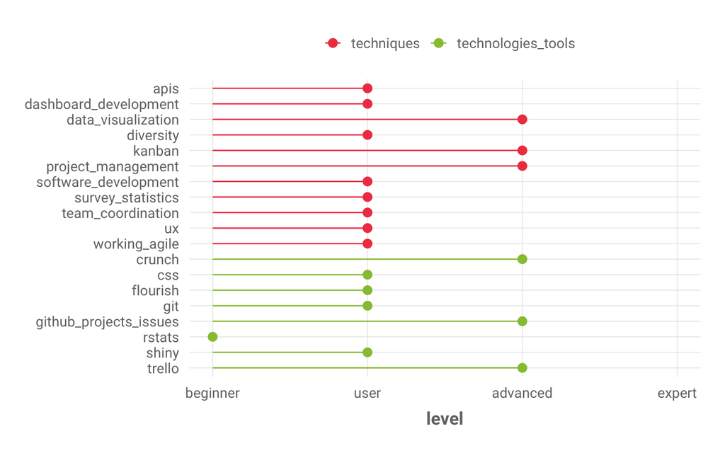

## 2026-12-EXA - shiny_dev_flourish_uiux

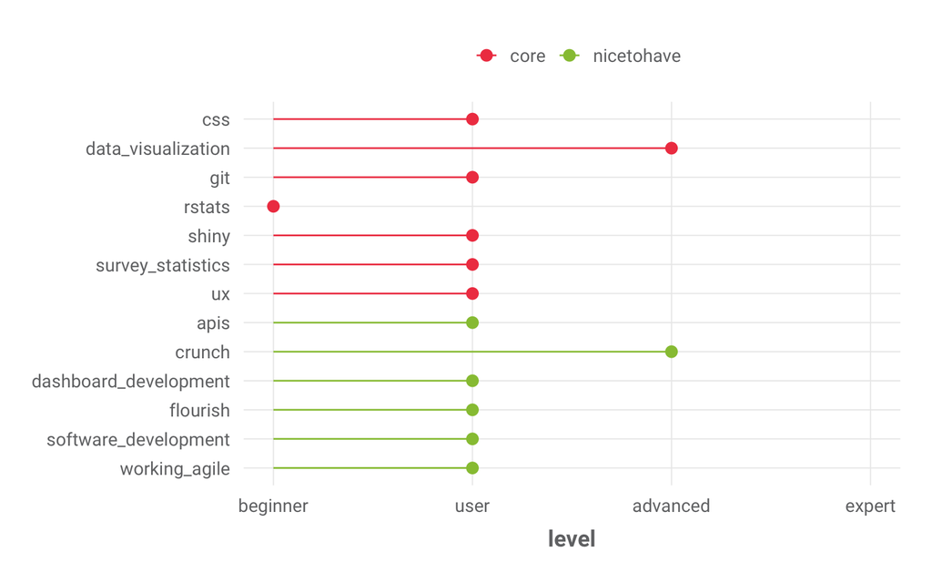

## 2026-12-EXA - team_coordinator

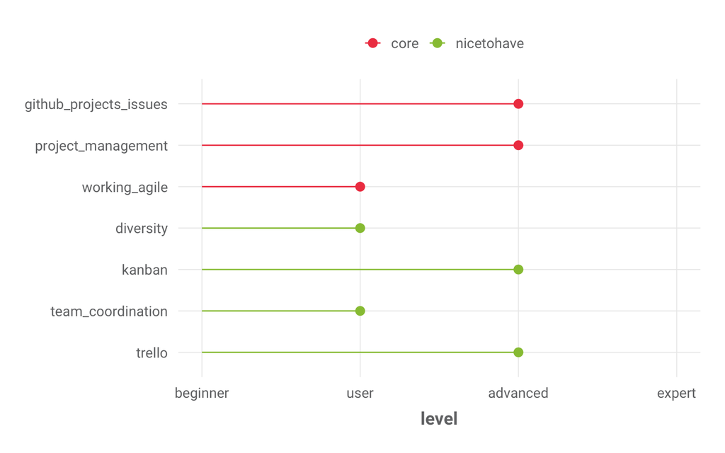

# 1916 - not_disclosed

**Gender**: not disclosed

**All applications:**

| project_id | project_role | score_core | score_nicetohave | # applications |
| --- | --- | --- | --- | --- |
| 2026-12-TES | team_trainee | 1.88 | 2.5 | 2 |

**German skills**: NA

**D4GV Workshops**: git_basics fit_tutor_de data4good_projects

**Team coordinator tasks**: help_team

**Past applications**

The applicant was **not successful** with their application(s) so far. They specified the following when asked about when/where they have applied in the past:

> NA

#### What skills qualify you?

test

#### Why do you want to get involved?

test

#### What do you want to learn as a team trainee?

test

### All self-rated skills

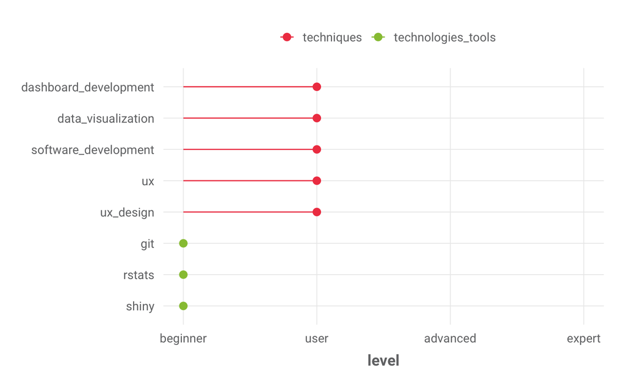

## 2026-12-TES - team_trainee

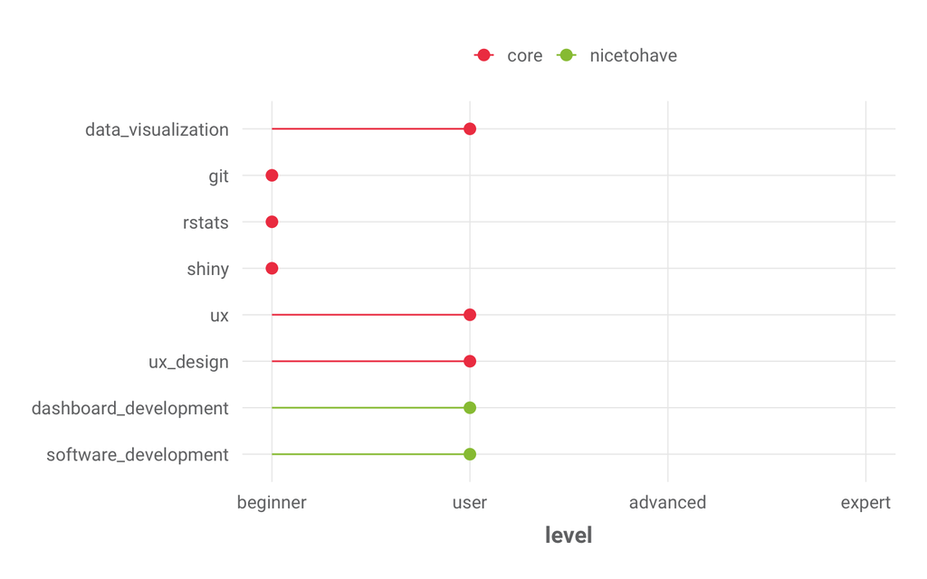

# 1976 - not_disclosed

**Gender**: not disclosed

**All applications:**

| project_id | project_role | score_core | score_nicetohave | # applications |
| --- | --- | --- | --- | --- |
| 2026-12-EXA | shiny_dev_flourish_uiux | 2.14 | 2.29 | 2 |
| 2026-12-EXA | volunteer_integrity_accuracy | 2.25 | 2.08 | 1 |
| 2026-12-TES | team_coordinator | 2.5 | 2.19 | 1 |
| 2026-12-TES | team_trainee | 2.08 | 1.88 | 2 |

**German skills**: NA

**D4GV Workshops**: git_advanced fit_tutor_en

**Team coordinator tasks**: applied as team coordinator.

**Past applications**

The applicant was **not successful** with their application(s) so far. They specified the following when asked about when/where they have applied in the past:

> foo

#### What skills qualify you?

i bring skills

#### Why do you want to get involved?

i bring skills

#### What do you want to learn as a team trainee?

test test

### All self-rated skills

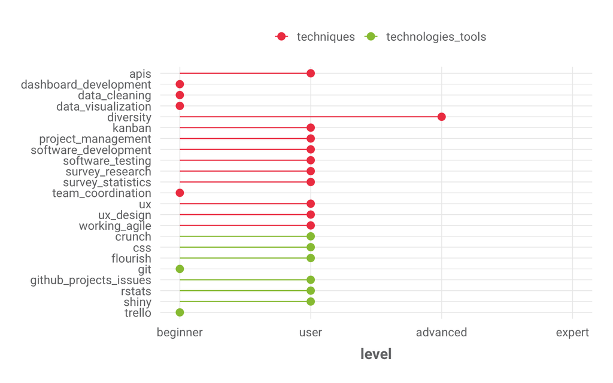

## 2026-12-EXA - shiny_dev_flourish_uiux

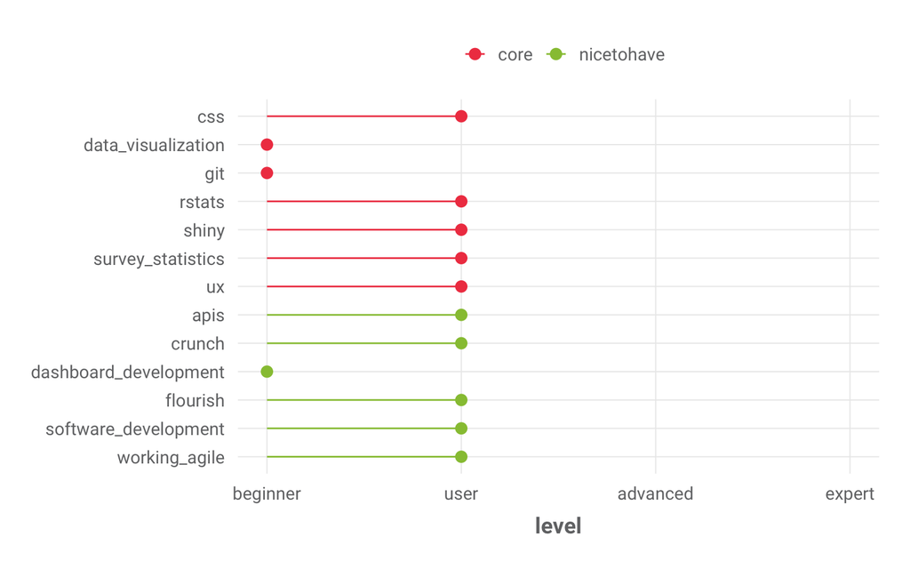

## 2026-12-EXA - volunteer_integrity_accuracy

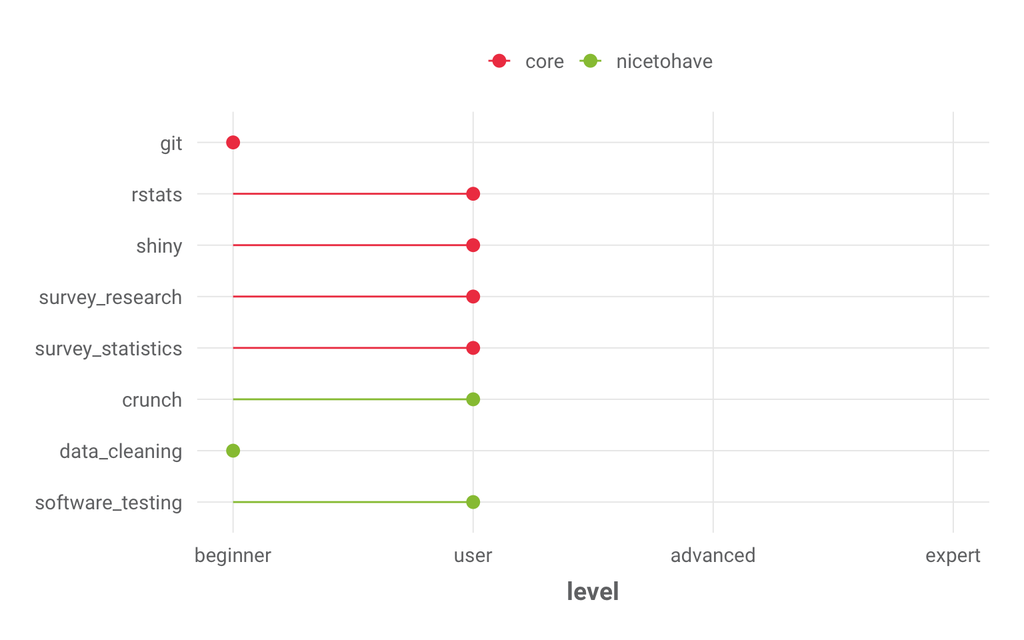

## 2026-12-TES - team_coordinator

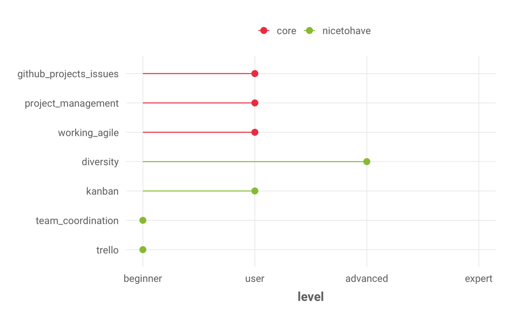

## 2026-12-TES - team_trainee

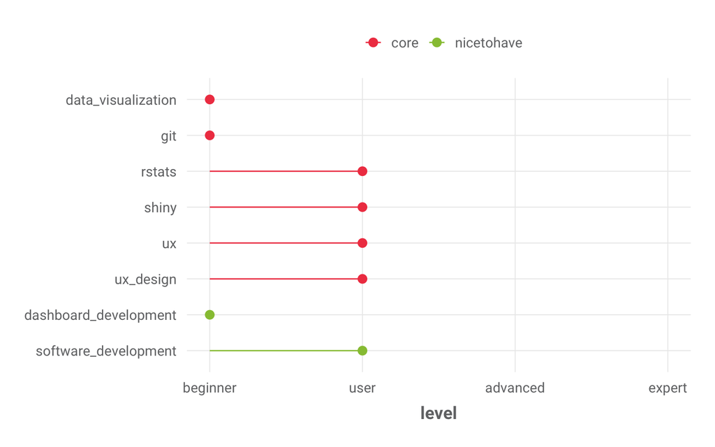

# 2012 - not_disclosed

**Gender**: not disclosed

**All applications:**

| project_id | project_role | score_core | score_nicetohave | # applications |
| --- | --- | --- | --- | --- |
| 2026-12-EXA | team_coordinator | 2.5 | 2.81 | 3 |

**German skills**: NA

**D4GV Workshops**: git_advanced fit_tutor_en

**Team coordinator tasks**: applied as team coordinator.

**Past applications**

The applicant has **successfully applied** to a CorrelAid project before.

#### What skills qualify you?

rste

#### Why do you want to get involved?

rste

#### What do you want to learn as a team trainee?

does not apply

### All self-rated skills

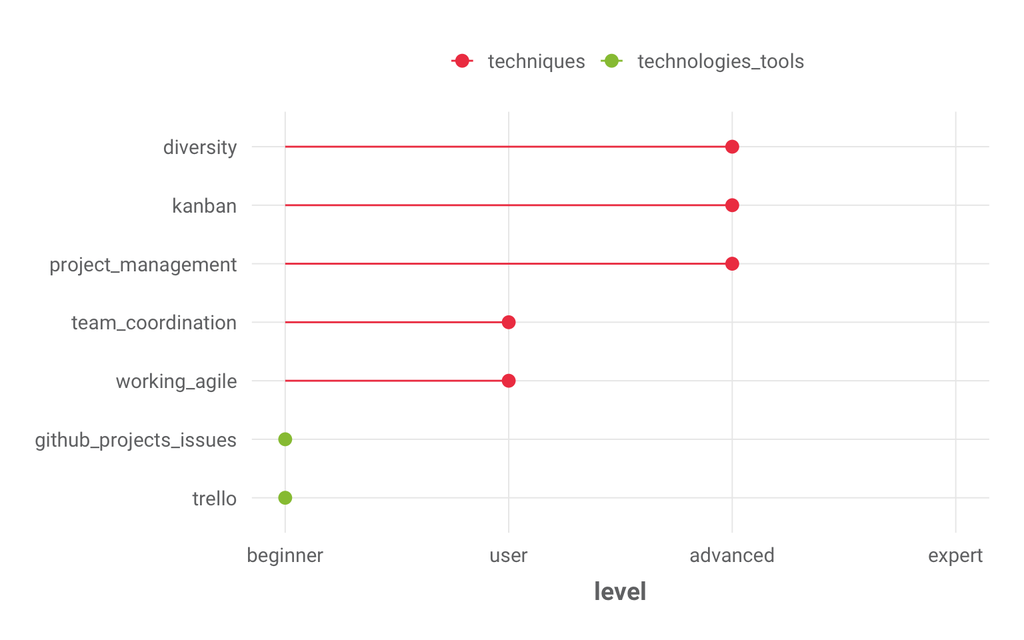

## 2026-12-EXA - team_coordinator

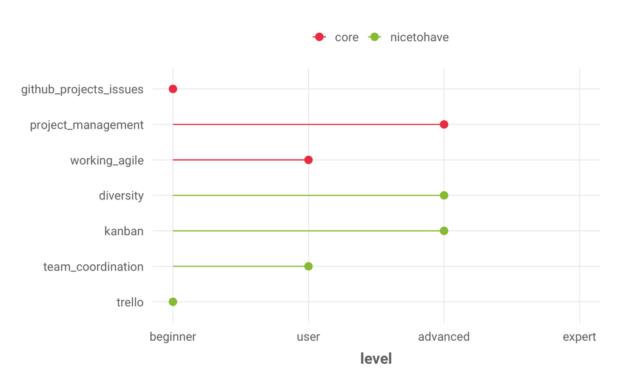

# 2013 - not_disclosed

**Gender**: not disclosed

**All applications:**

| project_id | project_role | score_core | score_nicetohave | # applications |
| --- | --- | --- | --- | --- |
| 2026-12-EXA | team_coordinator | 3.75 | 4.06 | 3 |

**German skills**: b1

**D4GV Workshops**: git_advanced fit_tutor_en

**Team coordinator tasks**: applied as team coordinator.

**Past applications**

The applicant was **not successful** with their application(s) so far. They specified the following when asked about when/where they have applied in the past:

> NA

#### What skills qualify you?

werwre

#### Why do you want to get involved?

werwre

#### What do you want to learn as a team trainee?

does not apply

### All self-rated skills

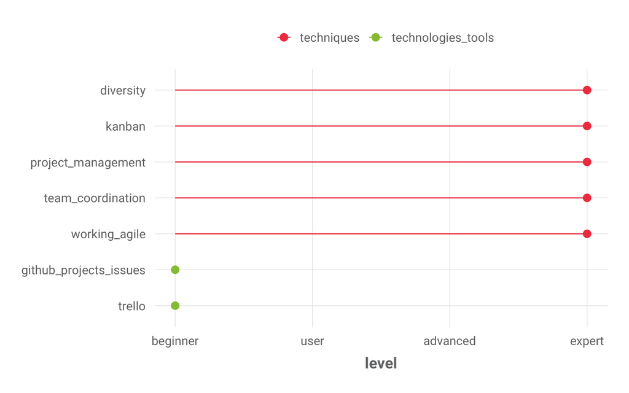

## 2026-12-EXA - team_coordinator

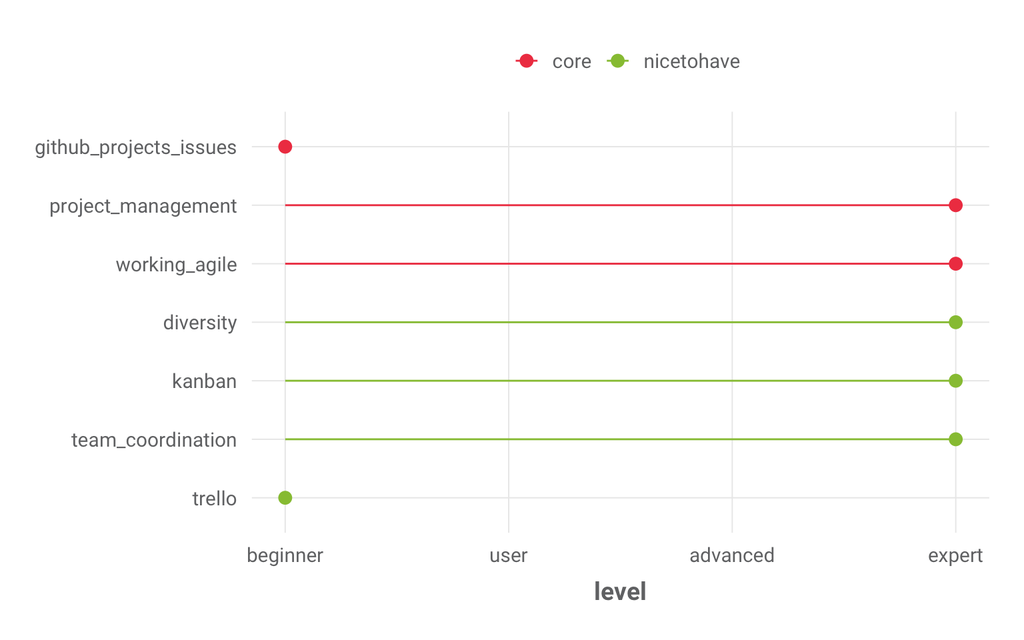